# Annual Report Data Analysis - Question 3.05 and 3.06

Tristan Burgess and Cristin Young

2026-04-07

# 3. Did EBP/CDEP services impact clinical and functional outcomes for clients who participated?

**Inclusion criteria:** 1. must have initial time point data (i.e., be enrolled in an intervention), 2. must have a valid assessment collected at both intake and discharge time points, and 3. limited to tools with a clinical cut-off.

**Scoring:** An **increase** in score indicates a positive outcome. There are no benchmarks or clinical cutoffs established for NOMS scoring — if the follow-up assessment score is higher than the initial score, a positive outcome is indicated.

**Assumptions:** Filtered out dates before 2024-01-01 and after the date the code was run. Filtered data that’s >3 days from initial assessment and paired to the LAST follow-up. Filtered positive outcomes that had NAs before computing %.

## 3.05 To what extent did parents/caregivers report improved daily life functioning for themselves and their child after receiving the intervention?

Range: 7–35; Sum = Q2a+…+Q2g.

Use the `pairs_primary_long_child` data frame to compute scores. The following had a positive outcome by follow-up quarter:

```
 positive_outcome   n percent
         worsened 122     17%
        no_change 138     19%
         improved 450     63%
```

Plot it.

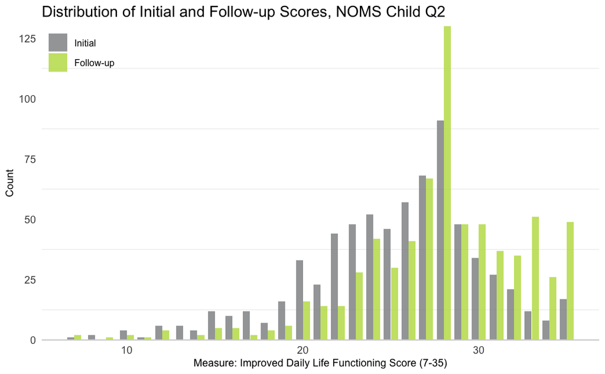

Ridgeline plot

| score_type | mean_score | median_score | sd_score | n |
| --- | --- | --- | --- | --- |
| Initial | 25.23521 | 26 | 5.001230 | 710 |
| Follow-up | 27.78169 | 28 | 4.763395 | 710 |

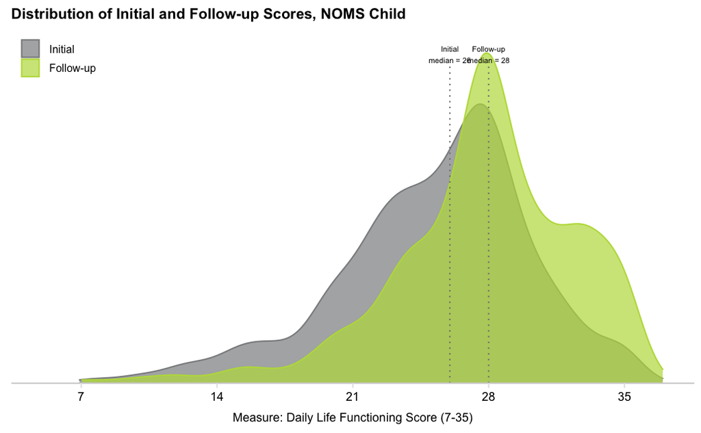

#### Summary stats

The percent of those who had total scores of 28 or higher (scores of 4*7 questions) across Q2 at initial and discharge time points were:

| initial_28 | followup_28 |
| --- | --- |
| 36.34 | 59.72 |

## 3.06 To what extent did the youth report improved daily life functioning after receiving the intervention?

Range: 7–35; Sum = Q2a+…+Q2g.

Use the `pairs_primary_long_self` data frame to compute scores. The following had a positive outcome by follow-up quarter:

```
 positive_outcome    n percent
         worsened 1144     47%
        no_change  190      8%
         improved 1079     45%
```

Plot it.

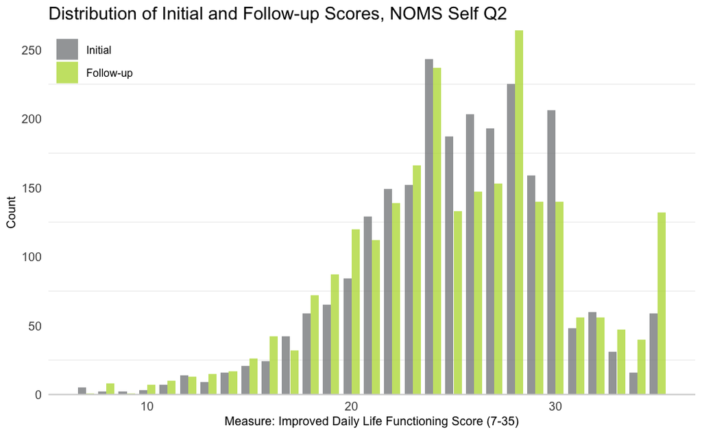

Ridgeline plot

| score_type | mean_score | median_score | sd_score | n | y_text |
| --- | --- | --- | --- | --- | --- |
| Initial | 25.14919 | 25 | 4.694758 | 2413 | 1.155 |
| Follow-up | 25.15914 | 25 | 5.290754 | 2413 | 1.165 |

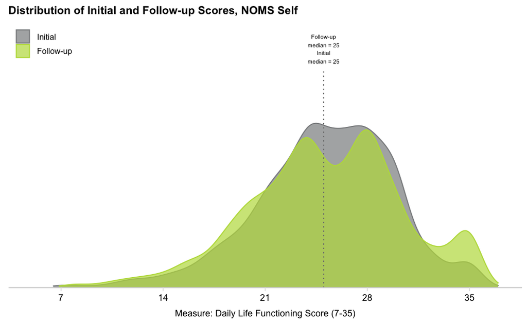

#### Summary stats

The percent of those who had total scores of 28 or higher (scores of 4*7 questions) across Q2 at initial and discharge time points were:

| initial_28 | followup_28 |
| --- | --- |
| 33.32 | 36.26 |

### Summary stats overall

[figure not shown]